# Capacity and Occupancy of the shelters in Toronto during COVID-19

Shuyu Duan

01/04/2021

Abstract

# Introduction

In this study, we used ggplot to explore the relationship between capacity and occupancy. Most of the shelters’ capacity is less than 250 and the occupancy for most of the shelters is less than 200. The ratio of the capacity and occupancy is about 1. Which means most of the shelters are about running out of space.

In this paper, I first described the data in the data set and how it is collected. Secondly, I indicated the relationship between capacity and occupancy. Then I explained the histogram for capacity, occupancy and their ratio. Finally, I point out the weakness of the survey and what we should do in the future.

# Data

```
## # A tibble: 1 x 11
##   title      id           topics civic_issues publisher excerpt dataset_category
##   <chr>      <chr>        <chr>  <chr>        <chr>     <chr>   <chr>
## 1 Daily She… 8a6eceb2-82… <NA>   <NA>         <NA>      <NA>    <NA>
## # … with 4 more variables: num_resources <int>, formats <chr>,
## #   refresh_rate <chr>, last_refreshed <date>
```

```
## # A tibble: 39,446 x 13
##    `_id` OCCUPANCY_DATE   ORGANIZATION_NAME     SHELTER_NAME    SHELTER_ADDRESS
##    <int> <chr>            <chr>                 <chr>           <chr>
##  1     1 2019-01-01T00:0… COSTI Immigrant Serv… COSTI Receptio… 100 Lippincott …
##  2     2 2019-01-01T00:0… COSTI Immigrant Serv… COSTI Receptio… 100 Lippincott …
##  3     3 2019-01-01T00:0… COSTI Immigrant Serv… COSTI Receptio… 100 Lippincott …
##  4     4 2019-01-01T00:0… COSTI Immigrant Serv… COSTI Receptio… 100 Lippincott …
##  5     5 2019-01-01T00:0… Christie Ossington N… Christie Ossin… 973 Lansdowne A…
##  6     6 2019-01-01T00:0… Christie Ossington N… Christie Ossin… 973 Lansdowne A…
##  7     7 2019-01-01T00:0… Christie Refugee Wel… Christie Refug… 43 Christie Str…
##  8     8 2019-01-01T00:0… City of Toronto       Birkdale Resid… 1229 Ellesmere …
##  9     9 2019-01-01T00:0… City of Toronto       Birkdale Resid… 1229 Ellesmere …
## 10    10 2019-01-01T00:0… City of Toronto       Birkdale Resid… 1229 Ellesmere …
## # … with 39,436 more rows, and 8 more variables: SHELTER_CITY <chr>,
## #   SHELTER_PROVINCE <chr>, SHELTER_POSTAL_CODE <chr>, FACILITY_NAME <chr>,
## #   PROGRAM_NAME <chr>, SECTOR <chr>, OCCUPANCY <int>, CAPACITY <int>
```

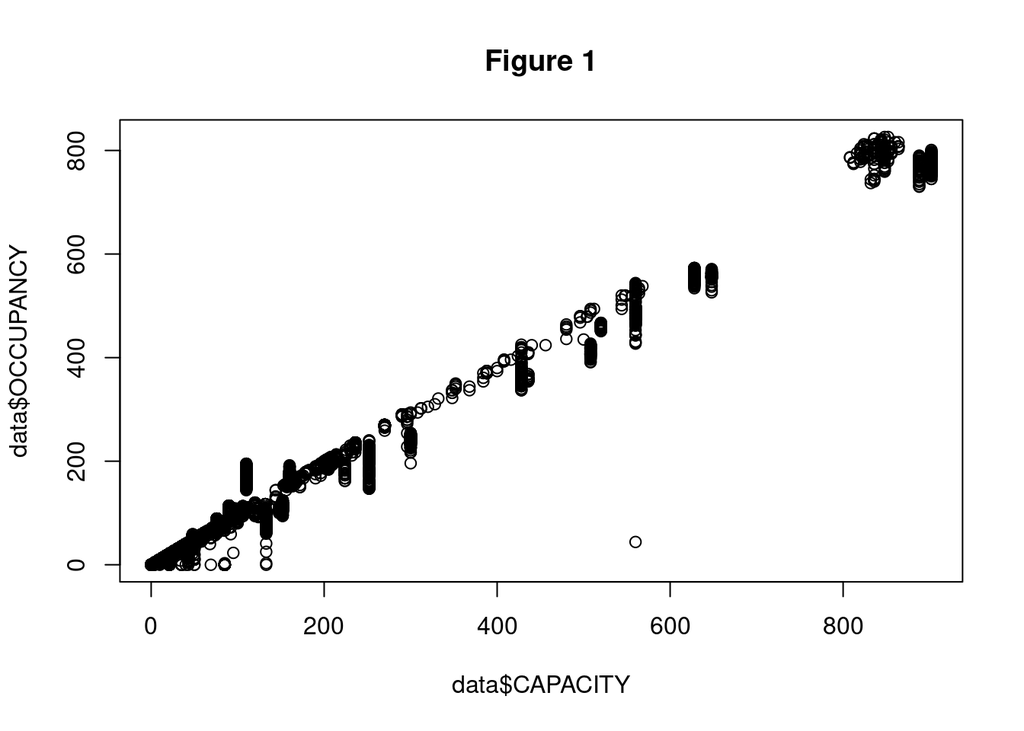

```
##     CAPACITY        OCCUPANCY
##  Min.   :  0.00   Min.   :  0.00
##  1st Qu.: 17.00   1st Qu.: 16.00
##  Median : 40.00   Median : 40.00
##  Mean   : 66.98   Mean   : 63.24
##  3rd Qu.: 74.00   3rd Qu.: 71.00
##  Max.   :902.00   Max.   :826.00
##  NA's   :65
```

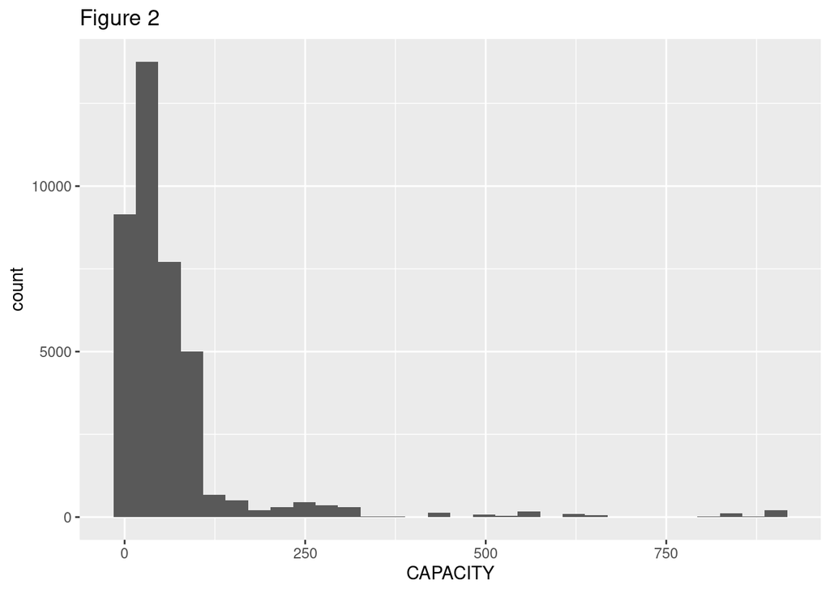

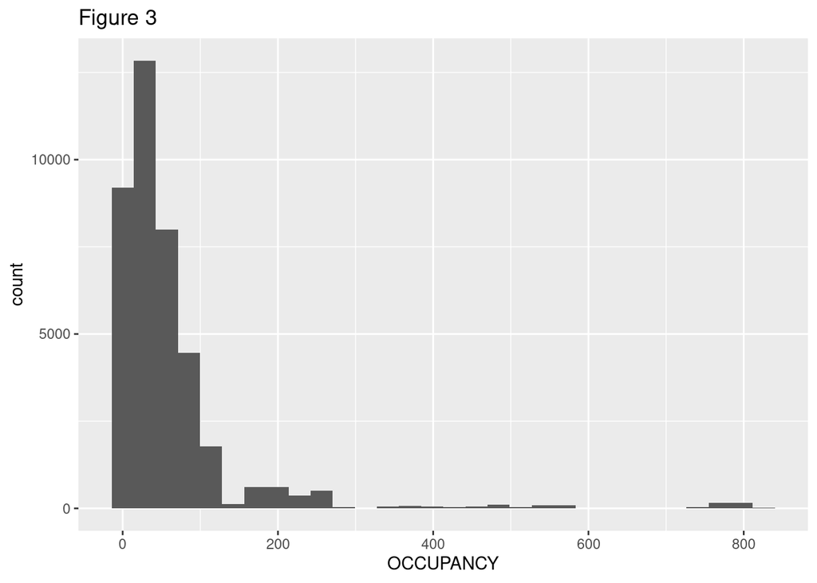

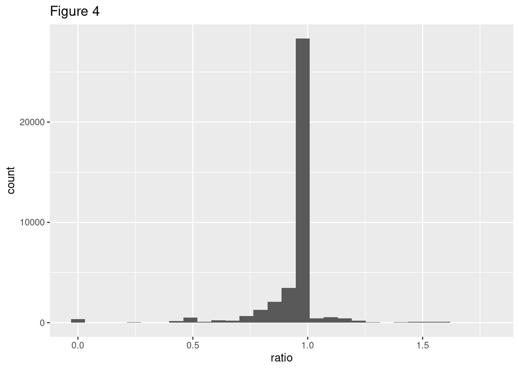

Figure 2 shows the distribution of capacity. The distribution is heavily right-skewed and the graph shows the capacity for most of the shelters is less than 250. Figure 3 shows the distribution of occupancy. The distribution is also heavily right-skewed and the graph shows the occupancy for most of the shelters is less than 200. Figure 4 shows the distribution for the ratio of capacity and occupancy. The distribution is left-skewed and the median of the distribution is about 1, which can reflect a problem that most of the shelters’ capacity is approaching saturation. The spaces in the shelters may not be enough for homeless people to stay during the COVID-19 period.

# Discussion

An article from the PressProgress states that “Toronto’s shelters are now consistently about 90% capacity”, which is right in our study. The shelters’ capacity is approaching saturation in Toronto and people live in such cloudy space is very dangerous. According to the City data, there is an increase in the COVID-19 cases in the shelters. Hundreds of people in the shelters have contracted COVID-19 and this may lead homeless people to live outdoors rather than indoors. The article “Toronto must defend the homeless” from CANADIAN CIVIL LIBERTIES ASSOCIATION(CCLA) also pointed out that the public facilities’ closure also affected the shelter users. Moreover, the closure and restriction on outdoor activities also limited the relief provided by private, charitable and public sectors.

The data set is not random sampling, and it can’t represent the population. Some factors can influence the result, such as COVID-19 can influence the shelters’ capacity and occupancy. The spaces available in the shelters may decrease to implement a physical distance. The occupancy date in the survey did not collect randomly, since the number of people who occupied the current date spaces only collects the next day at 4 AM.

# Weakness and next step

We should do more researches on how the capacity and occupancy changed in the shelters during the COVID-19 period. Then we can explore how the shelters in Toronto changed during this year. The government should build more shelters for the homeless people to ensure more spaces available for them to stay and keep physical distance to prevent coronavirus.

# References

- JJ Allaire and Yihui Xie and Jonathan McPherson and Javier Luraschi and Kevin Ushey and Aron Atkins and Hadley Wickham and Joe Cheng and Winston Chang and Richard Iannone (2020). rmarkdown: Dynamic Documents for R. R package version 2.3. URL https://rmarkdown.rstudio.com.
- Open Data Dataset. (n.d.). Retrieved March 2, 2021, from https://open.toronto.ca/dataset/daily-shelter-occupancy/
- Clapp, |. (2020, June 03). COVID-19 pushing homeless into encampments. Retrieved March 2, 2021, from http://spacing.ca/toronto/2020/06/03/covid-19-pushing-homeless-into-encampments/
- Toronto’s Shelters Are Now Consistently Above 90% Capacity – And That Is Extremely Dangerous. (2019, January 28). Retrieved March 10, 2021, from https://pressprogress.ca/torontos-shelters-are-now-consistently-above-90-capacity-and-that-is-extremely-dangerous/
- Toronto needs to take action to defend the homeless. (2020, July 06). Retrieved March 20, 2021, from https://ccla.org/toronto-must-defend-homeless/